# Modelos ARIMA intradía, regresión, datos de panel y GARCH para un portafolio de acciones del S&P 500

### 9.3.5 CPAY – cada 2 horas (10, 12, 14 y 16 h)

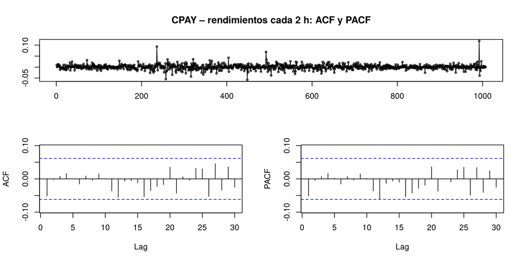

```
Series: ts(y)
ARIMA(0,1,0)
Box Cox transformation: lambda= 0

sigma^2 = 0.000133:  log likelihood = 3065
AIC=-6128   AICc=-6128   BIC=-6123
                ME  RMSE   MAE     MPE   MAPE   MASE     ACF1
Training set 0.181 4.058 2.626 0.04372 0.7608 0.9996 -0.07626
```

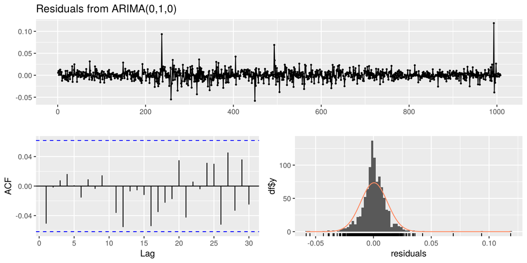

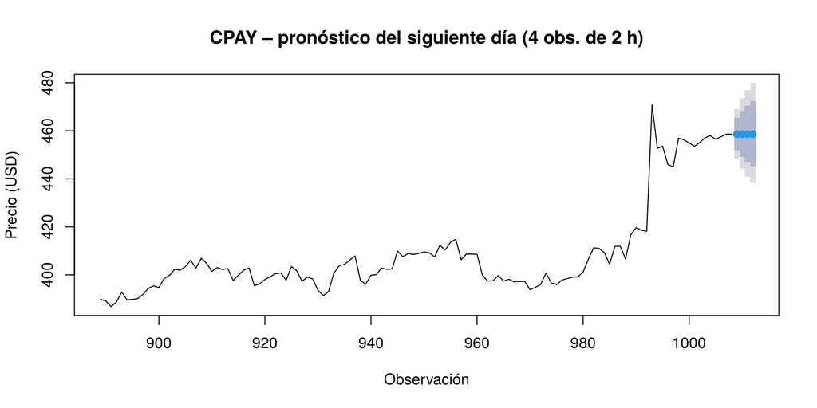

CPAY – pronóstico cada 2 h

| paso | hora | pronostico | li95 | ls95 |
| --- | --- | --- | --- | --- |
| 1 | 10:00 | 458.6 | 448.4 | 469.1 |
| 2 | 12:00 | 458.6 | 444.2 | 473.5 |
| 3 | 14:00 | 458.6 | 441.0 | 476.9 |
| 4 | 16:00 | 458.6 | 438.3 | 479.8 |

## 9.4 Resumen de los modelos ARIMA

```r
tabla_arima <- bind_rows(c(if (HAY_5MIN) unname(lapply(res_5min, `[[`, "resumen")),
                           unname(lapply(res_2h, `[[`, "resumen"))))
knitr::kable(tabla_arima, digits = 4, caption = "Modelos ARIMA por acción y frecuencia")
```

Modelos ARIMA por acción y frecuencia

| ticker | frecuencia | n | modelo | p_ADF_nivel | p_ADF_dif | p_KPSS_nivel | AICc | p_LjungBox | RMSE_ARIMA | RMSE_ingenuo | acierto_direccion | ultimo_precio | pronostico_final | li95 | ls95 |
| --- | --- | --- | --- | --- | --- | --- | --- | --- | --- | --- | --- | --- | --- | --- | --- |
| STX | 5 min | 1526 | ARIMA(0,1,3) c/deriva | 0.9869 | 0.01 | 0.01 | -9820 | 0.2608 | 2.8777 | 2.8679 | 0.4837 | 484.1 | 482.3 | 460.0 | 505.6 |
| VLO | 5 min | 1515 | ARIMA(2,1,3) c/deriva | 0.2967 | 0.01 | 0.01 | -11583 | 0.5649 | 1.3833 | 1.3506 | 0.4539 | 350.2 | 349.5 | 340.9 | 358.2 |
| DGX | 5 min | 1270 | ARIMA(3,1,0) c/deriva | 0.0384 | 0.01 | 0.01 | -10733 | 0.7191 | 0.3967 | 0.3966 | 0.4724 | 258.1 | 258.4 | 255.1 | 261.8 |
| NUE | 5 min | 1480 | ARIMA(0,1,3) | 0.8421 | 0.01 | 0.01 | -11613 | 0.0122 | 0.5992 | 0.6120 | 0.5135 | 256.6 | 256.5 | 250.7 | 262.6 |
| CPAY | 5 min | 1313 | ARIMA(0,1,3) | 0.7721 | 0.01 | 0.01 | -9571 | 0.0605 | 0.9006 | 0.8963 | 0.5682 | 458.4 | 458.5 | 446.1 | 471.1 |
| STX | 2 horas | 1008 | ARIMA(0,1,1) | 0.7826 | 0.01 | 0.01 | -4053 | 0.1146 | 17.6914 | 17.7204 | 0.4950 | 483.8 | 483.8 | 438.7 | 533.4 |
| VLO | 2 horas | 1008 | ARIMA(1,1,1) c/deriva | 0.2820 | 0.01 | 0.01 | -5297 | 0.4396 | 6.3042 | 6.2042 | 0.4455 | 350.2 | 351.4 | 334.4 | 369.2 |
| DGX | 2 horas | 1008 | ARIMA(4,1,0) | 0.3154 | 0.01 | 0.01 | -6183 | 0.5150 | 1.7431 | 1.7340 | 0.4950 | 258.1 | 258.0 | 250.3 | 266.1 |
| NUE | 2 horas | 1008 | ARIMA(0,1,4) c/deriva | 0.5776 | 0.01 | 0.01 | -5703 | 0.1731 | 3.4133 | 3.3913 | 0.4653 | 256.5 | 257.6 | 247.4 | 268.2 |
| CPAY | 2 horas | 1008 | ARIMA(0,1,0) | 0.1706 | 0.01 | 0.01 | -5589 | 0.7116 | 6.5754 | 6.5754 | NA | 458.6 | 458.6 | 438.3 | 479.8 |

```r
for (i in seq_len(nrow(tabla_arima))) {
  f <- tabla_arima[i, ]
  cat(sprintf("- **%s (%s)** → %s. ADF en nivel p = %.3f (%s) y en diferencias p = %.3f, por lo que el log-precio es I(%s). Ljung-Box p = %.3f: los residuales %s ruido blanco. Fuera de muestra, RMSE del ARIMA = %.4f vs. %.4f del modelo ingenuo (%s). Pronóstico al final del horizonte: %.2f USD (IC 95%%: %.2f – %.2f) contra el último precio de %.2f.\n",
              f$ticker, f$frecuencia, f$modelo, f$p_ADF_nivel,
              ifelse(f$p_ADF_nivel < 0.05, "estacionaria", "raíz unitaria"), f$p_ADF_dif,
              substr(f$modelo, 9, 9), f$p_LjungBox,
              ifelse(f$p_LjungBox >= 0.05, "sí son", "no son del todo"),
              f$RMSE_ARIMA, f$RMSE_ingenuo,
              ifelse(f$RMSE_ARIMA < f$RMSE_ingenuo, "mejora al ingenuo", "no supera al ingenuo"),
              f$pronostico_final, f$li95, f$ls95, f$ultimo_precio))
}
```

- **STX (5 min)** → ARIMA(0,1,3) c/deriva. ADF en nivel p = 0.987 (raíz unitaria) y en diferencias p = 0.010, por lo que el log-precio es I(1). Ljung-Box p = 0.261: los residuales sí son ruido blanco. Fuera de muestra, RMSE del ARIMA = 2.8777 vs. 2.8679 del modelo ingenuo (no supera al ingenuo). Pronóstico al final del horizonte: 482.30 USD (IC 95%: 460.03 – 505.64) contra el último precio de 484.07.
- **VLO (5 min)** → ARIMA(2,1,3) c/deriva. ADF en nivel p = 0.297 (raíz unitaria) y en diferencias p = 0.010, por lo que el log-precio es I(1). Ljung-Box p = 0.565: los residuales sí son ruido blanco. Fuera de muestra, RMSE del ARIMA = 1.3833 vs. 1.3506 del modelo ingenuo (no supera al ingenuo). Pronóstico al final del horizonte: 349.47 USD (IC 95%: 340.94 – 358.21) contra el último precio de 350.22.
- **DGX (5 min)** → ARIMA(3,1,0) c/deriva. ADF en nivel p = 0.038 (estacionaria) y en diferencias p = 0.010, por lo que el log-precio es I(1). Ljung-Box p = 0.719: los residuales sí son ruido blanco. Fuera de muestra, RMSE del ARIMA = 0.3967 vs. 0.3966 del modelo ingenuo (no supera al ingenuo). Pronóstico al final del horizonte: 258.42 USD (IC 95%: 255.11 – 261.78) contra el último precio de 258.09.
- **NUE (5 min)** → ARIMA(0,1,3). ADF en nivel p = 0.842 (raíz unitaria) y en diferencias p = 0.010, por lo que el log-precio es I(1). Ljung-Box p = 0.012: los residuales no son del todo ruido blanco. Fuera de muestra, RMSE del ARIMA = 0.5992 vs. 0.6120 del modelo ingenuo (mejora al ingenuo). Pronóstico al final del horizonte: 256.55 USD (IC 95%: 250.68 – 262.55) contra el último precio de 256.59.
- **CPAY (5 min)** → ARIMA(0,1,3). ADF en nivel p = 0.772 (raíz unitaria) y en diferencias p = 0.010, por lo que el log-precio es I(1). Ljung-Box p = 0.060: los residuales sí son ruido blanco. Fuera de muestra, RMSE del ARIMA = 0.9006 vs. 0.8963 del modelo ingenuo (no supera al ingenuo). Pronóstico al final del horizonte: 458.45 USD (IC 95%: 446.10 – 471.15) contra el último precio de 458.43.
- **STX (2 horas)** → ARIMA(0,1,1). ADF en nivel p = 0.783 (raíz unitaria) y en diferencias p = 0.010, por lo que el log-precio es I(1). Ljung-Box p = 0.115: los residuales sí son ruido blanco. Fuera de muestra, RMSE del ARIMA = 17.6914 vs. 17.7204 del modelo ingenuo (mejora al ingenuo). Pronóstico al final del horizonte: 483.77 USD (IC 95%: 438.73 – 533.43) contra el último precio de 483.75.
- **VLO (2 horas)** → ARIMA(1,1,1) c/deriva. ADF en nivel p = 0.282 (raíz unitaria) y en diferencias p = 0.010, por lo que el log-precio es I(1). Ljung-Box p = 0.440: los residuales sí son ruido blanco. Fuera de muestra, RMSE del ARIMA = 6.3042 vs. 6.2042 del modelo ingenuo (no supera al ingenuo). Pronóstico al final del horizonte: 351.38 USD (IC 95%: 334.43 – 369.18) contra el último precio de 350.19.
- **DGX (2 horas)** → ARIMA(4,1,0). ADF en nivel p = 0.315 (raíz unitaria) y en diferencias p = 0.010, por lo que el log-precio es I(1). Ljung-Box p = 0.515: los residuales sí son ruido blanco. Fuera de muestra, RMSE del ARIMA = 1.7431 vs. 1.7340 del modelo ingenuo (no supera al ingenuo). Pronóstico al final del horizonte: 258.04 USD (IC 95%: 250.26 – 266.06) contra el último precio de 258.09.
- **NUE (2 horas)** → ARIMA(0,1,4) c/deriva. ADF en nivel p = 0.578 (raíz unitaria) y en diferencias p = 0.010, por lo que el log-precio es I(1). Ljung-Box p = 0.173: los residuales sí son ruido blanco. Fuera de muestra, RMSE del ARIMA = 3.4133 vs. 3.3913 del modelo ingenuo (no supera al ingenuo). Pronóstico al final del horizonte: 257.58 USD (IC 95%: 247.40 – 268.19) contra el último precio de 256.46.
- **CPAY (2 horas)** → ARIMA(0,1,0). ADF en nivel p = 0.171 (raíz unitaria) y en diferencias p = 0.010, por lo que el log-precio es I(1). Ljung-Box p = 0.712: los residuales sí son ruido blanco. Fuera de muestra, RMSE del ARIMA = 6.5754 vs. 6.5754 del modelo ingenuo (no supera al ingenuo). Pronóstico al final del horizonte: 458.60 USD (IC 95%: 438.33 – 479.80) contra el último precio de 458.60.

**Lectura general.** En frecuencias intradía es común que el mejor modelo sea muy cercano a una **caminata aleatoria** (ARIMA(0,1,0) o con términos AR/MA pequeños). Esto es consistente con la **hipótesis de mercados eficientes en su forma débil**: el precio pasado casi no predice el siguiente. El valor del ARIMA está en **cuantificar la incertidumbre** (los intervalos crecen con el horizonte) y en detectar pequeñas autocorrelaciones (por ejemplo, el rebote del *bid-ask* en 5 min, que aparece como un MA(1) negativo).

# 10 GARCH: volatilidad condicional (puntos extra)

Se estima un **AR(1)-GARCH(1,1)** con distribución *t* de Student sobre los rendimientos diarios (en %) y se compara contra un **GJR-GARCH** (efecto apalancamiento: las caídas aumentan más la volatilidad que las subidas).

$$\sigma^2_t = \omega + \alpha_1
\varepsilon^2_{t-1} + \beta_1 \sigma^2_{t-1}$$

```r
spec_garch <- ugarchspec(variance.model = list(model = "sGARCH", garchOrder = c(1, 1)),
                         mean.model = list(armaOrder = c(1, 0), include.mean = TRUE),
                         distribution.model = "std")
spec_gjr   <- ugarchspec(variance.model = list(model = "gjrGARCH", garchOrder = c(1, 1)),
                         mean.model = list(armaOrder = c(1, 0), include.mean = TRUE),
                         distribution.model = "std")

res_garch <- list()
tabla_garch <- purrr::map_dfr(SELECCION, function(t) {
  r   <- 100 * rend[, t]
  fit <- ugarchfit(spec_garch, data = r, solver = "hybrid")
  gjr <- ugarchfit(spec_gjr,   data = r, solver = "hybrid")
  fc  <- ugarchforecast(fit, n.ahead = 10)
  cf  <- coef(fit)
  q05 <- qdist("std", p = 0.05, mu = 0, sigma = 1, shape = cf["shape"])
  var1 <- as.numeric(fitted(fc)[1] + sigma(fc)[1] * q05)          # VaR 95% a 1 día (en %)
  res_garch[[t]] <<- list(fit = fit, fc = fc)
  tibble(ticker = t, omega = cf["omega"], alpha1 = cf["alpha1"], beta1 = cf["beta1"],
         persistencia = persistence(fit),
         vida_media_dias = log(0.5) / log(persistence(fit)),
         vol_actual_anual = as.numeric(xts::last(sigma(fit))) * sqrt(252),
         vol_pronostico_anual = as.numeric(sigma(fc)[1]) * sqrt(252),
         VaR95_1d_pct = var1,
         AIC_sGARCH = infocriteria(fit)[1], AIC_GJR = infocriteria(gjr)[1],
         gamma_GJR = coef(gjr)["gamma1"])
})
knitr::kable(tabla_garch, digits = 4, caption = "GARCH(1,1) con t de Student y comparación con GJR-GARCH")
```

GARCH(1,1) con t de Student y comparación con GJR-GARCH

| ticker | omega | alpha1 | beta1 | persistencia | vida_media_dias | vol_actual_anual | vol_pronostico_anual | VaR95_1d_pct | AIC_sGARCH | AIC_GJR | gamma_GJR |
| --- | --- | --- | --- | --- | --- | --- | --- | --- | --- | --- | --- |
| STX | 0.1736 | 0.0782 | 0.9081 | 0.9864 | 50.502 | 106.10 | 109.28 | -10.232 | 4.750 | 4.751 | -0.0051 |
| VLO | 0.2224 | 0.0655 | 0.9050 | 0.9706 | 23.196 | 53.56 | 52.72 | -5.156 | 4.656 | 4.654 | 0.0399 |
| DGX | 0.1746 | 0.0971 | 0.8339 | 0.9310 | 9.698 | 24.81 | 24.78 | -2.375 | 3.501 | 3.502 | -0.0056 |
| NUE | 0.1313 | 0.0439 | 0.9372 | 0.9811 | 36.245 | 43.26 | 42.62 | -4.015 | 4.494 | 4.494 | 0.0259 |
| CPAY | 0.2793 | 0.0989 | 0.8471 | 0.9459 | 12.469 | 41.39 | 39.09 | -3.671 | 4.151 | 4.141 | 0.1182 |

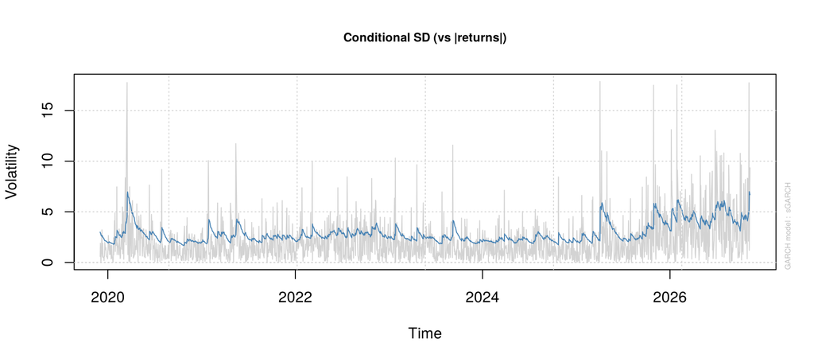

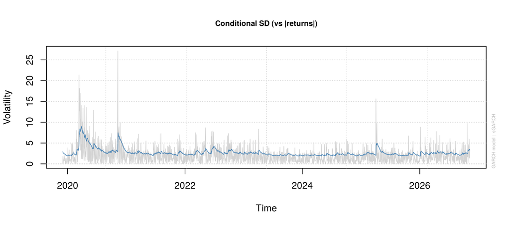

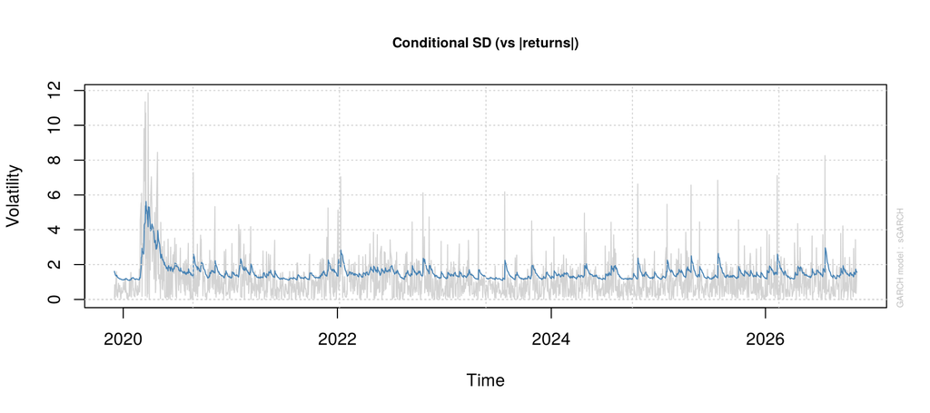

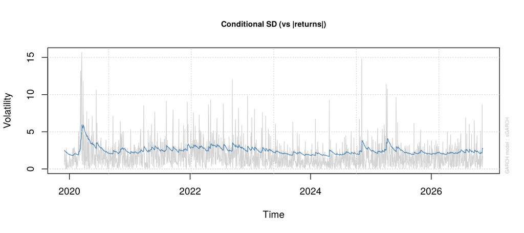

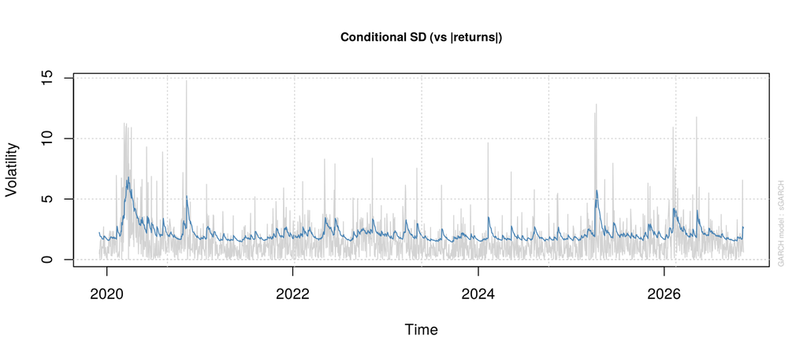

```r
for (t in SELECCION) plot(res_garch[[t]]$fit, which = 3)
```

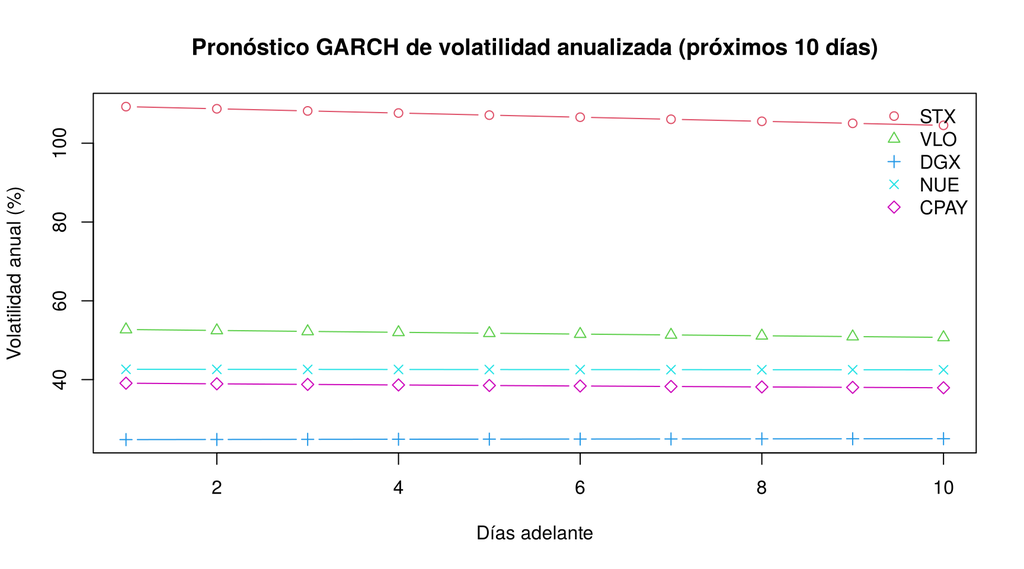

```r
pron_vol <- sapply(res_garch, function(g) as.numeric(sigma(g$fc)))
matplot(1:10, pron_vol * sqrt(252), type = "b", pch = 1:5, col = 2:6, lty = 1,
        main = "Pronóstico GARCH de volatilidad anualizada (próximos 10 días)",
        xlab = "Días adelante", ylab = "Volatilidad anual (%)")
legend("topright", SELECCION, col = 2:6, pch = 1:5, bty = "n")
```

**Interpretación.** `alpha1` mide la reacción a las noticias de ayer y `beta1` la memoria de la volatilidad. Si la **persistencia** (alpha1 + beta1) está cerca de 1, los choques de volatilidad tardan mucho en disiparse (la vida media dice cuántos días tarda en reducirse a la mitad). Si el AIC del GJR es menor y `gamma1` > 0, existe **efecto apalancamiento**. El VaR al 95 % indica la pérdida diaria que solo se rebasaría 1 de cada 20 días.

# 11 Portafolio: tipo, pesos y número de acciones

**Tipo de portafolio:** de **crecimiento con diversificación sectorial**, construido con optimización **media-varianza de Markowitz** (máximo índice de Sharpe) y límites de peso por acción (mínimo 10 %, máximo 30 %), para que ninguna empresa domine y todas participen.

Los rendimientos esperados se estiman con un promedio de dos enfoques (`METODO_MU = "mixto"`): el **histórico** (que tiende a sobrestimar a las acciones que ya subieron mucho) y el del **CAPM**, $E[r_i] = r_f + \beta_i \cdot \text{prima}$, que usa las betas de la regresión simple. Así se reduce el sesgo por desempeño pasado.

```r
METODO_MU <- "mixto"   # "historico", "capm" o "mixto"

mu_esperado <- function(tickers) {
  hist <- colMeans(rend[, tickers]) * 252
  capm <- RF_ANUAL + tabla_rls$beta[match(tickers, tabla_rls$ticker)] * PRIMA_MDO
  switch(METODO_MU, historico = hist, capm = setNames(capm, tickers),
         mixto = 0.5 * hist + 0.5 * setNames(capm, tickers))
}

optimizar <- function(tickers, w_min = 0.10, w_max = 0.30, n_sim = 30000, semilla = 123) {
  k <- length(tickers); mu <- mu_esperado(tickers); S <- cov(rend[, tickers]) * 252
  set.seed(semilla)
  D <- matrix(rexp(n_sim * k), ncol = k); D <- D / rowSums(D)
  W <- w_min + (1 - k * w_min) * D            # garantiza el peso mínimo
  W <- W[apply(W, 1, max) <= w_max, , drop = FALSE]
  colnames(W) <- tickers
  ret <- as.numeric(W %*% mu); vol <- sqrt(rowSums((W %*% S) * W))
  sharpe <- (ret - RF_ANUAL) / vol
  list(W = W, ret = ret, vol = vol, sharpe = sharpe, mu = mu, S = S,
       w_sharpe = W[which.max(sharpe), ], w_minvar = W[which.min(vol), ])
}

calcular_acciones <- function(w, precio, capital = CAPITAL) {
  n <- floor(w * capital / precio)
  sobrante <- capital - sum(n * precio)
  repeat {                                   # invierte el sobrante en la acción más subponderada
    cand <- which(precio <= sobrante)
    if (length(cand) == 0) break
    brecha <- w - n * precio / capital
    j <- cand[which.max(brecha[cand])]
    n[j] <- n[j] + 1; sobrante <- sobrante - precio[j]
  }
  tibble(ticker = names(w), peso_objetivo = as.numeric(w), precio = as.numeric(precio),
         acciones = as.integer(n), monto = as.numeric(n * precio),
         peso_real = as.numeric(n * precio / capital)) %>%
    bind_rows(tibble(ticker = "Efectivo", monto = sobrante, peso_real = sobrante / capital))
}

# Último precio disponible: 5 min de Refinitiv si existe; si no, el cierre diario
ultimo_precio <- function(tickers) {
  sapply(tickers, function(t) {
    if (exists("serie_5min") && !is.null(serie_5min[[t]])) as.numeric(xts::last(serie_5min[[t]]))
    else as.numeric(xts::last(precios[, t]))
  })
}
```

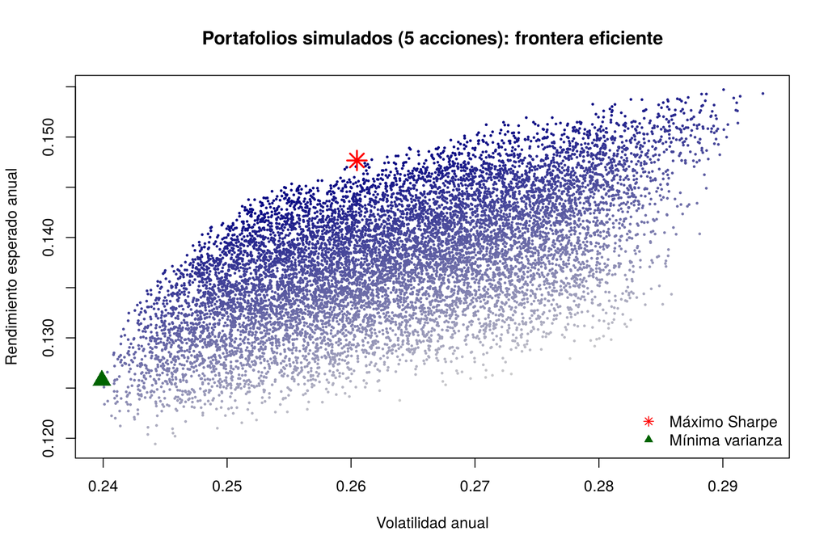

```r
opt5 <- optimizar(SELECCION)
plot(opt5$vol, opt5$ret, pch = 20, cex = 0.4, col = colorRampPalette(c("grey80", "navy"))(100)[cut(opt5$sharpe, 100)],
     main = "Portafolios simulados (5 acciones): frontera eficiente", xlab = "Volatilidad anual", ylab = "Rendimiento esperado anual")
points(opt5$vol[which.max(opt5$sharpe)], opt5$ret[which.max(opt5$sharpe)], pch = 8, cex = 2, col = "red", lwd = 2)
points(opt5$vol[which.min(opt5$vol)], opt5$ret[which.min(opt5$vol)], pch = 17, cex = 2, col = "darkgreen")
legend("bottomright", c("Máximo Sharpe", "Mínima varianza"), pch = c(8, 17), col = c("red", "darkgreen"), bty = "n")
```

```r
pesos <- rbind(`Máximo Sharpe` = opt5$w_sharpe, `Mínima varianza` = opt5$w_minvar,
               `Pesos iguales` = rep(1 / 5, 5))
knitr::kable(round(100 * pesos, 1), caption = "Pesos (%) de las estrategias candidatas")
```

Pesos (%) de las estrategias candidatas

|  | STX | VLO | DGX | NUE | CPAY |
| --- | --- | --- | --- | --- | --- |
| Máximo Sharpe | 29.2 | 11.4 | 25.7 | 23.3 | 10.3 |
| Mínima varianza | 17.7 | 12.2 | 29.9 | 12.6 | 27.6 |
| Pesos iguales | 20.0 | 20.0 | 20.0 | 20.0 | 20.0 |

```r
precio_hoy <- ultimo_precio(SELECCION)
compra <- calcular_acciones(opt5$w_sharpe, precio_hoy[SELECCION])
knitr::kable(compra, digits = c(0, 4, 2, 0, 2, 4),
             caption = sprintf("Acciones a comprar con USD %s (portafolio de máximo Sharpe)",
                               format(CAPITAL, big.mark = ",", nsmall = 2)))
```

Acciones a comprar con USD 943,990.81 (portafolio de máximo Sharpe)

| ticker | peso_objetivo | precio | acciones | monto | peso_real |
| --- | --- | --- | --- | --- | --- |
| STX | 0.2924 | 484.1 | 570 | 275919.9 | 0.2923 |
| VLO | 0.1140 | 350.2 | 307 | 107517.5 | 0.1139 |
| DGX | 0.2573 | 258.1 | 941 | 242862.7 | 0.2573 |
| NUE | 0.2330 | 256.6 | 857 | 219897.6 | 0.2329 |
| CPAY | 0.1033 | 458.4 | 213 | 97645.6 | 0.1034 |
| Efectivo | NA | NA | NA | 147.5 | 0.0002 |

```r
# Versión de 10 acciones para el reporte (mismo capital, peso mínimo de 5% y máximo de 20%)
opt10    <- optimizar(TODAS, w_min = 0.05, w_max = 0.20)
compra10 <- calcular_acciones(opt10$w_sharpe, ultimo_precio(TODAS))
knitr::kable(compra10, digits = c(0, 4, 2, 0, 2, 4), caption = "Escenario alterno: portafolio de 10 acciones")
```

Escenario alterno: portafolio de 10 acciones

| ticker | peso_objetivo | precio | acciones | monto | peso_real |
| --- | --- | --- | --- | --- | --- |
| STX | 0.1752 | 484.07 | 342 | 165551.9 | 0.1754 |
| VLO | 0.0555 | 350.22 | 149 | 52182.8 | 0.0553 |
| DGX | 0.1470 | 258.09 | 537 | 138594.3 | 0.1468 |
| NUE | 0.0630 | 256.59 | 231 | 59272.3 | 0.0628 |
| CPAY | 0.0537 | 458.43 | 111 | 50885.7 | 0.0539 |
| AAPL | 0.1839 | 350.69 | 495 | 173591.5 | 0.1839 |
| MSFT | 0.1114 | 545.18 | 193 | 105219.7 | 0.1115 |
| JPM | 0.0768 | 342.08 | 212 | 72521.0 | 0.0768 |
| KO | 0.0603 | 96.03 | 593 | 56945.8 | 0.0603 |
| XOM | 0.0734 | 164.73 | 420 | 69186.6 | 0.0733 |
| Efectivo | NA | NA | NA | 39.1 | 0.0000 |

# 12 Modelos para las estrategias del portafolio

## 12.1 Estrategia 1 – Estratégica (comprar y mantener con rebalanceo trimestral)

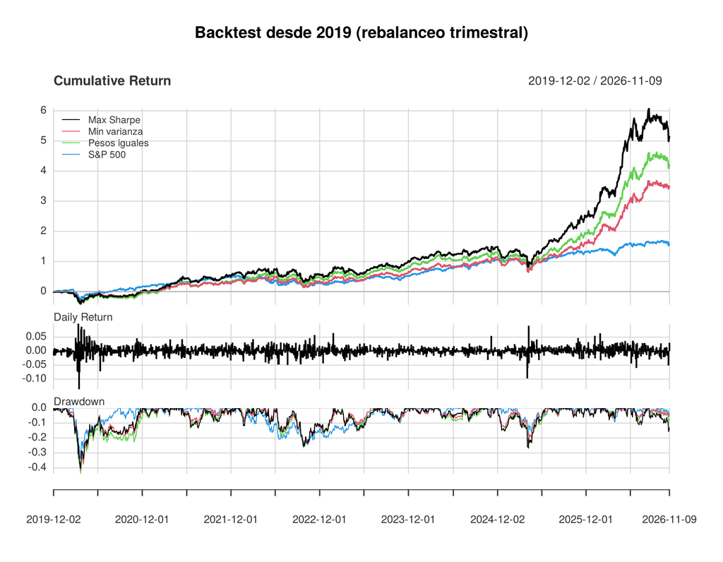

```r
R_simple <- exp(rend[, SELECCION]) - 1
bt <- merge(
  Sharpe   = Return.portfolio(R_simple, weights = opt5$w_sharpe, rebalance_on = "quarters"),
  MinVar   = Return.portfolio(R_simple, weights = opt5$w_minvar, rebalance_on = "quarters"),
  Iguales  = Return.portfolio(R_simple, weights = rep(0.2, 5),   rebalance_on = "quarters"),
  SP500    = exp(fac$mercado) - 1)
bt <- na.omit(bt); colnames(bt) <- c("Max Sharpe", "Min varianza", "Pesos iguales", "S&P 500")
charts.PerformanceSummary(bt, main = "Backtest desde 2019 (rebalanceo trimestral)")
```

```r
knitr::kable(resumen_desempeno(bt), digits = 4)
```

|  | Max Sharpe | Min varianza | Pesos iguales | S&P 500 |
| --- | --- | --- | --- | --- |
| Annualized Return | 0.3125 | 0.2531 | 0.2804 | 0.1532 |
| Annualized Std Dev | 0.2632 | 0.2409 | 0.2613 | 0.2019 |
| Annualized Sharpe (Rf=4%) | 0.9921 | 0.8470 | 0.8813 | 0.5351 |
| Máxima caída | 0.4041 | 0.4144 | 0.4390 | 0.3392 |

*Advertencia:* los pesos se optimizaron con la misma muestra, así que el backtest es optimista (sesgo *in-sample*). Sirve para comparar perfiles de riesgo, no para prometer rendimientos.

## 12.2 Estrategia 2 – Táctica con señales ARIMA de 2 horas

Regla: en cada observación de 2 horas, si el ARIMA pronostica un precio **mayor** al actual se mantiene la posición; si pronostica uno **menor**, se pasa a efectivo. Se evalúa solo en la muestra de prueba (fuera de muestra) y se descuentan costos de transacción.

```r
tabla_tactica <- purrr::map_dfr(SELECCION, function(t) {
  p <- res_2h[[t]]$prueba
  r_real <- log(p$real / p$previo)
  senal  <- as.numeric(p$pred > p$previo)
  cambios <- c(senal[1], abs(diff(senal)))
  r_estr <- senal * r_real - cambios * COSTO_TRADE
  tibble(ticker = t, obs_prueba = length(r_real),
         rend_comprar_mantener = exp(sum(r_real)) - 1,
         rend_estrategia_ARIMA = exp(sum(r_estr)) - 1,
         tiempo_invertido = mean(senal), operaciones = sum(cambios))
})
knitr::kable(tabla_tactica, digits = 4, caption = "Estrategia ARIMA de 2 h vs. comprar y mantener (fuera de muestra)")
```

Estrategia ARIMA de 2 h vs. comprar y mantener (fuera de muestra)

| ticker | obs_prueba | rend_comprar_mantener | rend_estrategia_ARIMA | tiempo_invertido | operaciones |
| --- | --- | --- | --- | --- | --- |
| STX | 101 | -0.3983 | -0.2610 | 0.6337 | 47 |
| VLO | 101 | -0.1672 | -0.1878 | 0.9109 | 7 |
| DGX | 101 | 0.1372 | 0.0289 | 0.5545 | 58 |
| NUE | 101 | 0.0154 | -0.0154 | 0.6337 | 39 |
| CPAY | 101 | 0.1386 | -0.0222 | 0.3663 | 50 |

## 12.3 Estrategia 3 – Gestión de riesgo con GARCH (volatilidad objetivo y VaR)

La exposición al portafolio se ajusta cada día a $\min(1.5,\; \sigma_{objetivo} / \hat\sigma_t)$, donde $\hat\sigma_t$ es la volatilidad pronosticada por un GARCH del portafolio. Cuando el GARCH anticipa turbulencia, se reduce la exposición.

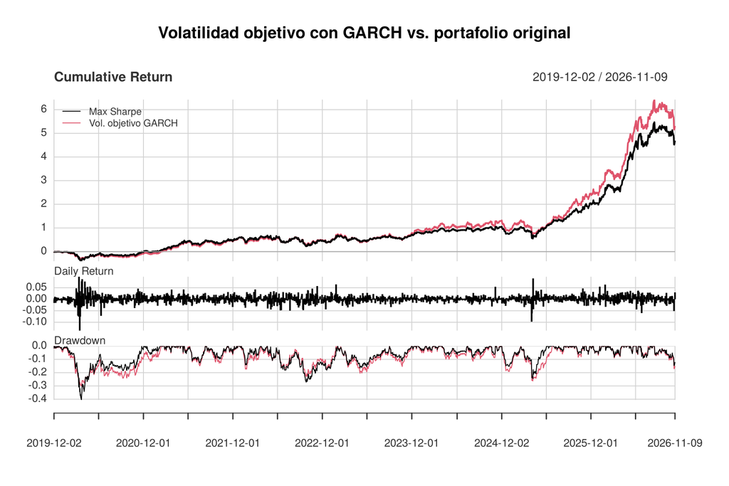

```r
rp <- 100 * Return.portfolio(R_simple, weights = opt5$w_sharpe, rebalance_on = "quarters")
fit_p <- ugarchfit(spec_garch, data = rp, solver = "hybrid")
sig_p <- sigma(fit_p)                                   # sigma_t usa información hasta t-1
vol_obj <- as.numeric(sd(rp))                           # objetivo = volatilidad histórica promedio
expo <- pmin(1.5, vol_obj / sig_p)
r_vt <- expo * rp / 100 - abs(diff(expo)) * COSTO_TRADE
r_vt[1] <- 0
comp <- na.omit(merge(rp / 100, r_vt)); colnames(comp) <- c("Max Sharpe", "Vol. objetivo GARCH")
charts.PerformanceSummary(comp, main = "Volatilidad objetivo con GARCH vs. portafolio original")
```

```r
knitr::kable(resumen_desempeno(comp), digits = 4)
```

|  | Max Sharpe | Vol. objetivo GARCH |
| --- | --- | --- |
| Annualized Return | 0.2855 | 0.3050 |
| Annualized Std Dev | 0.2620 | 0.2617 |
| Annualized Sharpe (Rf=4%) | 0.8976 | 0.9700 |
| Máxima caída | 0.4055 | 0.3011 |

```r
fc_p <- ugarchforecast(fit_p, n.ahead = 1)
q05  <- qdist("std", p = 0.05, mu = 0, sigma = 1, shape = coef(fit_p)["shape"])
VaR_pct <- as.numeric(fitted(fc_p) + sigma(fc_p) * q05)
valor_inv <- sum(compra$monto[compra$ticker != "Efectivo"])
cat(sprintf("VaR 95%% a 1 día del portafolio: %.2f%% = USD %s\n", VaR_pct,
            format(round(valor_inv * VaR_pct / 100, 2), big.mark = ",")))
```

```
## VaR 95% a 1 día del portafolio: -3.27% = USD -30,899
```

## 12.4 Pronóstico del valor del portafolio (ARIMA de 2 horas)

```r
n_acc <- setNames(compra$acciones[compra$ticker %in% SELECCION], compra$ticker[compra$ticker %in% SELECCION])
efectivo <- compra$monto[compra$ticker == "Efectivo"]
pron <- sapply(SELECCION, function(t) as.numeric(res_2h[[t]]$fc$mean))
li   <- sapply(SELECCION, function(t) as.numeric(res_2h[[t]]$fc$lower[, 2]))
ls   <- sapply(SELECCION, function(t) as.numeric(res_2h[[t]]$fc$upper[, 2]))
valor <- data.frame(hora = paste0(HORAS_2H[1:H_2H], ":00"),
                    valor_pronosticado = as.numeric(pron %*% n_acc[SELECCION]) + efectivo,
                    escenario_bajo_95 = as.numeric(li %*% n_acc[SELECCION]) + efectivo,
                    escenario_alto_95 = as.numeric(ls %*% n_acc[SELECCION]) + efectivo)
knitr::kable(valor, digits = 2, format.args = list(big.mark = ","),
             caption = "Valor pronosticado del portafolio para la siguiente sesión")
```

Valor pronosticado del portafolio para la siguiente sesión

| hora | valor_pronosticado | escenario_bajo_95 | escenario_alto_95 |
| --- | --- | --- | --- |
| 10:00 | 944,448 | 917,464 | 972,430 |
| 12:00 | 944,612 | 907,491 | 983,632 |
| 14:00 | 944,828 | 900,077 | 992,371 |
| 16:00 | 945,012 | 893,771 | 999,939 |

Los escenarios bajo y alto suman los extremos de cada acción, así que son **conservadores**: suponen que todas se mueven juntas al extremo.

# 13 Ejecución de órdenes con IBrokers (opcional, cuenta *paper*)

Conecta el algoritmo con lo visto en la clase del 26 de octubre. **No se ejecuta al compilar** (`eval=FALSE`). Úsalo solo con la cuenta de simulación (puerto 7497) y con TWS abierto.

```r
library(IBrokers)
tws <- twsConnect(port = 7497)
isConnected(tws)
for (i in seq_len(nrow(compra))) {
  if (compra$ticker[i] == "Efectivo" || compra$acciones[i] == 0) next
  contrato <- twsEquity(compra$ticker[i], exch = "SMART", primary = ifelse(compra$ticker[i] == "STX", "NASDAQ", "NYSE"))
  orden_id <- as.numeric(reqIds(tws))
  orden <- twsOrder(orden_id, orderType = "MKT", action = "BUY",
                    totalQuantity = as.character(compra$acciones[i]), transmit = TRUE)
  placeOrder(tws, contrato, orden)
  Sys.sleep(1)
}
twsDisconnect(tws)
```

# 14 Conclusiones

```r
cat(sprintf("1. **Selección.** Se eligieron %s, cinco empresas de sectores distintos con rendimiento sobresaliente que no son las acciones típicas del índice.\n",
            paste(SELECCION, collapse = ", ")))
```

1. **Selección.** Se eligieron STX, VLO, DGX, NUE, CPAY, cinco empresas de sectores distintos con rendimiento sobresaliente que no son las acciones típicas del índice.

```r
cat(sprintf("2. **Regresión simple.** La beta más alta es la de %s (%.2f) y la más baja la de %s (%.2f): el portafolio combina acciones agresivas y defensivas.\n",
            tabla_rls$ticker[which.max(tabla_rls$beta)], max(tabla_rls$beta),
            tabla_rls$ticker[which.min(tabla_rls$beta)], min(tabla_rls$beta)))
```

2. **Regresión simple.** La beta más alta es la de STX (1.21) y la más baja la de KO (0.49): el portafolio combina acciones agresivas y defensivas.

```r
cat("3. **Regresión múltiple.** Además del mercado, el petróleo explica a las energéticas y la tasa a 10 años a las acciones sensibles al crédito. Hay heterocedasticidad, por lo que se usan errores robustos y GARCH.\n")
```

3. **Regresión múltiple.** Además del mercado, el petróleo explica a las energéticas y la tasa a 10 años a las acciones sensibles al crédito. Hay heterocedasticidad, por lo que se usan errores robustos y GARCH.

```r
if (exists("nombre_panel")) cat(sprintf("4. **Panel.** Las pruebas F y de Hausman eligen el modelo de %s para explicar la *outperformance* trimestral.\n", nombre_panel))
```

4. **Panel.** Las pruebas F y de Hausman eligen el modelo de agrupado (pooled) para explicar la *outperformance* trimestral.

```r
if (exists("tabla_arima")) cat(sprintf("5. **ARIMA.** En %d de %d casos el ARIMA tuvo menor error que el modelo ingenuo. Los precios intradía se comportan casi como una caminata aleatoria, así que el ARIMA es más útil para medir la incertidumbre que para predecir la dirección.\n",
            sum(tabla_arima$RMSE_ARIMA < tabla_arima$RMSE_ingenuo), nrow(tabla_arima)))
```

5. **ARIMA.** En 2 de 10 casos el ARIMA tuvo menor error que el modelo ingenuo. Los precios intradía se comportan casi como una caminata aleatoria, así que el ARIMA es más útil para medir la incertidumbre que para predecir la dirección.

```r
cat(sprintf("6. **GARCH.** La persistencia promedio es de %.3f: la volatilidad se agrupa y persiste, lo que justifica la estrategia de volatilidad objetivo.\n",
            mean(tabla_garch$persistencia)))
```

6. **GARCH.** La persistencia promedio es de 0.963: la volatilidad se agrupa y persiste, lo que justifica la estrategia de volatilidad objetivo.

```r
cat(sprintf("7. **Portafolio.** Con USD %s se invierte en el portafolio de máximo Sharpe (detalle en la tabla de acciones), con un sobrante en efectivo de USD %s.\n",
            format(CAPITAL, big.mark = ",", nsmall = 2),
            format(round(compra$monto[compra$ticker == "Efectivo"], 2), big.mark = ",")))
```

7. **Portafolio.** Con USD 943,990.81 se invierte en el portafolio de máximo Sharpe (detalle en la tabla de acciones), con un sobrante en efectivo de USD 147.5.

*Este trabajo es académico y no constituye una recomendación de inversión.*